# Random Forest using Titanic Dataset

Himansu Sahoo

January 14, 2015

This is the example showing how to use random forest algorithm in titanic dataset to predict survival rate of passengers. We will use R built-in function **randomforest** to model the dataset.

link to kaggle competition : https://www.kaggle.com/c/titanic

### Step 1 : Getting the Data into R

```r
train_raw <- read.csv(file="../datasets/titanic-train.csv", na.strings=c(""," ", "NA", "NAN"))
test_raw <- read.csv(file="../datasets/titanic-test.csv", na.strings=c(""," ", "NA", "NAN"))
# stringsAsFactors=TRUE by default
# treat all empty values, NAN as NA's
```

#### Check the training dataset

```r
# use dplyr
library(dplyr)
train_raw <- tbl_df(train_raw)
test_raw <- tbl_df(test_raw)

dim(train_raw)
```

```
## [1] 891  12
```

```r
# the dataset contains 891 rows/observations and 12 variables
#nrow(train_raw); ncol(train_raw)
#head(train_raw) # print first 6 rows
#tail(train_raw) # print last 6 rows
#str(train_raw) # will show class of each variable
# 'data.frame':    891 obs. of  12 variables:
#summary(train_raw)
#glimpse(train_raw) # dplyr version of str()
# names(train_raw) # also same as colnames(train_raw)
```

Looking at `str(train_raw)`  
Name : Factor w/ 891 levels  
Ticket : Factor w/ 681 levels  
Cabin : Factor w/ 147 levels

Name and ticket are strings, they are read as factors.  
Looking at `summary(train_raw)`, Age has 177 NA’s, Cabin has 687 NA’s, Embarked has 2 NA’s.

#### Check the testing dataset

```r
dim(test_raw)
```

```
## [1] 418  11
```

```r
#str(test_raw)
#'data.frame':    418 obs. of  11 variables:
# one variable is less from training set, i.e. the response variable Survived
#summary(test_raw)
```

Looking at `str(test_raw)`  
Name : Factor w/ 418 levels  
Ticket : Factor w/ 363 levels  
Cabin : Factor w/ 76 levels

Looking at *summary(test_raw)*, Fare has 1 NA, Cabin has 327 NA’s.

#### Removing Variables

First, look at first 100 rows : head(train_raw, n=100) or dplyr version print(train_raw, n=100) PassengerId is unique of each row, Name is not necessary, Ticket also. Remove these three variables from train_raw and make new dataset train_final. using str(train_raw), we see that Cabin has 147 levels. remove this also from data.

```r
colnames(train_raw) # same as just names()
```

```
##  [1] "PassengerId" "Survived"    "Pclass"      "Name"        "Sex"
##  [6] "Age"         "SibSp"       "Parch"       "Ticket"      "Fare"
## [11] "Cabin"       "Embarked"
```

```r
remove_variables <- c("PassengerId", "Name", "Ticket", "Cabin")
##train_final <- train_raw[, !names(train_raw) %in% remove_variables]
train_final <- train_raw %>% select(-c(PassengerId, Name, Ticket, Cabin))
names(train_final)
```

```
## [1] "Survived" "Pclass"   "Sex"      "Age"      "SibSp"    "Parch"
## [7] "Fare"     "Embarked"
```

```r
test_final <- test_raw
```

#### Checking NA values

```r
colSums(is.na(train_final))
```

```
## Survived   Pclass      Sex      Age    SibSp    Parch     Fare Embarked
##        0        0        0      177        0        0        0        2
```

```r
#summary(train_final)
print(class(train_final$Survived))
```

```
## [1] "integer"
```

```r
print(str(train_final$Survived))
```

```
##  int [1:891] 0 1 1 1 0 0 0 0 1 1 ...
## NULL
```

```r
train_final$Survived <- as.factor(train_final$Survived)
print(class(train_final$Survived))
```

```
## [1] "factor"
```

```r
print(str(train_final$Survived))
```

```
##  Factor w/ 2 levels "0","1": 1 2 2 2 1 1 1 1 2 2 ...
## NULL
```

Age has 177, Embarked has 2 missing values. We have changed the response variable to a factor variable, otherwise randomForest formula will give problem.

#### Splitting data into training and validation set

We will use the `createDataPartition` function in `caret` package to split the `train_data` into 70% train_set and valid_set. Set seed in the beginning to reproduce the same result in future.

```r
library(caret)
#######train_final <- train_raw # assign only when you don't have train_final
set.seed(1099)
inTrain <- createDataPartition(y=train_final$Survived, p=0.70, list=FALSE)
train_set <- train_final[inTrain,]
valid_set <- train_final[-inTrain,]
```

```r
train_per <- (nrow(train_set)/nrow(train_final))*100
valid_per <- (nrow(valid_set)/nrow(train_final))*100
# we printed below to make sure that train set have 70% and validation set has 30% observations.
cat("******** training dataset is : ", train_per, "% \n")
```

```
## ******** training dataset is :  70.1459 %
```

```r
cat("******** validation dataset is : ", valid_per, "% \n")
```

```
## ******** validation dataset is :  29.8541 %
```

### Step 2 : Building a Random Forest Model using randomforest function

We will use the R built-in function **randomforest** to build the **randomforest** model.

```r
library(randomForest)
#rf_model <- randomForest(Survived~., data=train_set)
# explicitly mention variable names
#rf_model <- randomForest(Survived~Pclass+Sex+Age+SibSp+Parch+Fare+Embarked, data=train_set)
# this is same as above, 7 predictors
# remove the missing values, Age and Embarked
rf_model <- randomForest(Survived~Pclass+Sex+SibSp+Parch+Fare, data=train_set)
# make sure that response variable is factor variable
```

remove the missing values before doing modeling. Change the response variable to a factor variable for classification.

[output not shown]

#### Print different model functions

```r
class(rf_model) # "randomForest.formula" "randomForest"
```

```
## [1] "randomForest.formula" "randomForest"
```

```r
print(rf_model)
```

```
##
## Call:
##  randomForest(formula = Survived ~ Pclass + Sex + SibSp + Parch +      Fare, data = train_set)
##                Type of random forest: classification
##                      Number of trees: 500
## No. of variables tried at each split: 2
##
##         OOB estimate of  error rate: 21.76%
## Confusion matrix:
##     0   1 class.error
## 0 334  51   0.1324675
## 1  85 155   0.3541667
```

```r
names(rf_model)
```

```
##  [1] "call"            "type"            "predicted"
##  [4] "err.rate"        "confusion"       "votes"
##  [7] "oob.times"       "classes"         "importance"
## [10] "importanceSD"    "localImportance" "proximity"
## [13] "ntree"           "mtry"            "forest"
## [16] "y"               "test"            "inbag"
## [19] "terms"
```

```r
ls(rf_model)
```

```
##  [1] "call"            "classes"         "confusion"
##  [4] "err.rate"        "forest"          "importance"
##  [7] "importanceSD"    "inbag"           "localImportance"
## [10] "mtry"            "ntree"           "oob.times"
## [13] "predicted"       "proximity"       "terms"
## [16] "test"            "type"            "votes"
## [19] "y"
```

```r
rf_model$call
```

```
## randomForest(formula = Survived ~ Pclass + Sex + SibSp + Parch +
##     Fare, data = train_set)
```

```r
rf_model$type # "classification"
```

```
## [1] "classification"
```

```r
rf_model$classes # "0" "1"
```

```
## [1] "0" "1"
```

```r
rf_model$confusion # print confusion matrix
```

```
##     0   1 class.error
## 0 334  51   0.1324675
## 1  85 155   0.3541667
```

```r
rf_model$importance # MeanDecreaseGini importance, output is a matrix
```

```
##        MeanDecreaseGini
## Pclass         26.42782
## Sex            74.02729
## SibSp          11.59610
## Parch          12.95174
## Fare           54.05176
```

```r
rf_model$mtry # 2
```

```
## [1] 2
```

```r
rf_model$ntree # 500
```

```
## [1] 500
```

#### Plot the Model

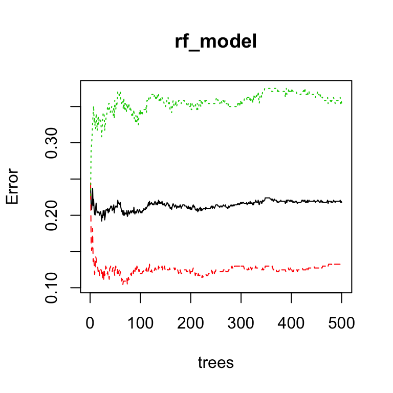

```r
plot(rf_model) # plot Error vrs. number of trees
```

#### Print variable importance

```r
rf_model$importance
```

```
##        MeanDecreaseGini
## Pclass         26.42782
## Sex            74.02729
## SibSp          11.59610
## Parch          12.95174
## Fare           54.05176
```

```r
var_imp <- varImp(rf_model) # takes a randomForest object
class(var_imp) # data.frame
```

```
## [1] "data.frame"
```

```r
print(var_imp)
```

```
##         Overall
## Pclass 26.42782
## Sex    74.02729
## SibSp  11.59610
## Parch  12.95174
## Fare   54.05176
```

```r
rownames(var_imp)
```

```
## [1] "Pclass" "Sex"    "SibSp"  "Parch"  "Fare"
```

```r
colnames(var_imp)
```

```
## [1] "Overall"
```

```r
# add row names as one variable, and sort by decreasing
var_imp$var <- rownames(var_imp)
print(var_imp)
```

```
##         Overall    var
## Pclass 26.42782 Pclass
## Sex    74.02729    Sex
## SibSp  11.59610  SibSp
## Parch  12.95174  Parch
## Fare   54.05176   Fare
```

```r
var_imp <- var_imp %>% arrange(desc(Overall))
print(var_imp)
```

```
##    Overall    var
## 1 74.02729    Sex
## 2 54.05176   Fare
## 3 26.42782 Pclass
## 4 12.95174  Parch
## 5 11.59610  SibSp
```